# Gradebook Analysis

Ha Thuong Tran

2024-01-06

## Load packages

```r
# Load libraries
library(tidyverse)
library(here)
library(readxl)
library(janitor)
library(dataedu)
library(corrplot)
library(car)
library("olsrr")
```

## Import data

```r
# See the current working directory
getwd()
```

```r
# Use readxl package to read and import file and assign it a name
ExcelGradeBook <-
  read_excel(
    here("ExcelGradeBook.xlsx"),
    sheet = 1,
    skip = 10
  )
```

```r
# Rename data frame
gradebook <- ExcelGradeBook
```

## Process data

```r
#Rename the columns
gradebook <-
  gradebook %>%
  clean_names()
```

```r
# Remove rows that contain nothing but NA values
gradebook <- gradebook[rowSums(is.na(gradebook)) < ncol(gradebook), ]

# Remove unneeded columns
unneeded_columns <- c("repeated_grades", "make_your_own_categories", "another_type_2", "assessment_insert_new_columns_before_here")
gradebook <- gradebook[, !(names(gradebook) %in% unneeded_columns)]
```

## Data analysis

### RQ1: What is the relationship between formative and summative assessments?

**Linearity**

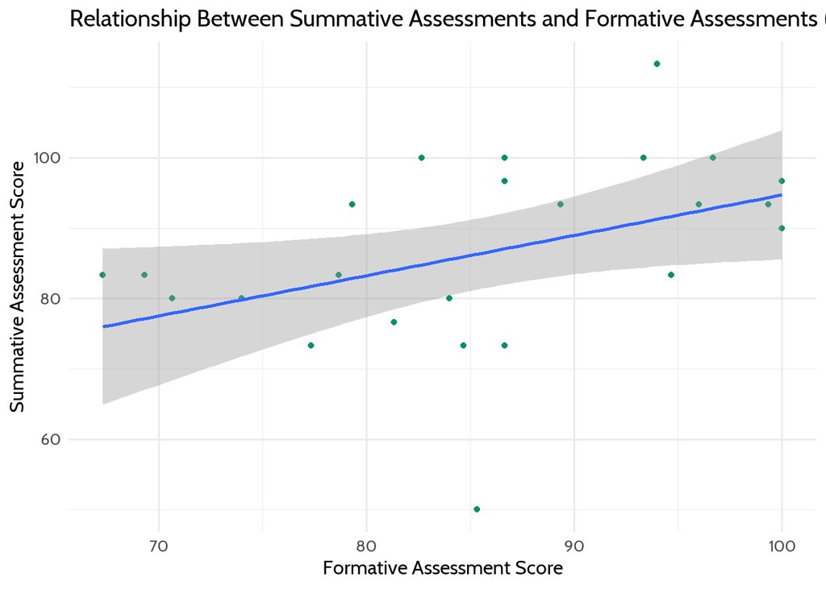

```r
# Scatter plot between formative assessment and summative assessments
# To determine linear relationship
# With line of best fit
gradebook %>%
  ggplot(aes(x = formative_assessments,
             y = summative_assessments)) +
  geom_point(color = dataedu_colors("green")) +
  geom_smooth(method = "lm",
              se = TRUE) +
  labs(title = "Relationship Between Summative Assessments and Formative Assessments (with Line of Best Fit)",
       x = "Formative Assessment Score",
       y = "Summative Assessment Score") +
  theme_dataedu()
```

**Normal distribution**

```r
column_to_check <- gradebook$summative_assessments

# Shapiro-Wilk normality test
shapiro.test(column_to_check)
```

```
##
##  Shapiro-Wilk normality test
##
## data:  column_to_check
## W = 0.94357, p-value = 0.1789
```

Since the p-value is greater than 0.05, the null hypothesis is not rejected, suggesting that the data may be normally distributed.

**Outliers**

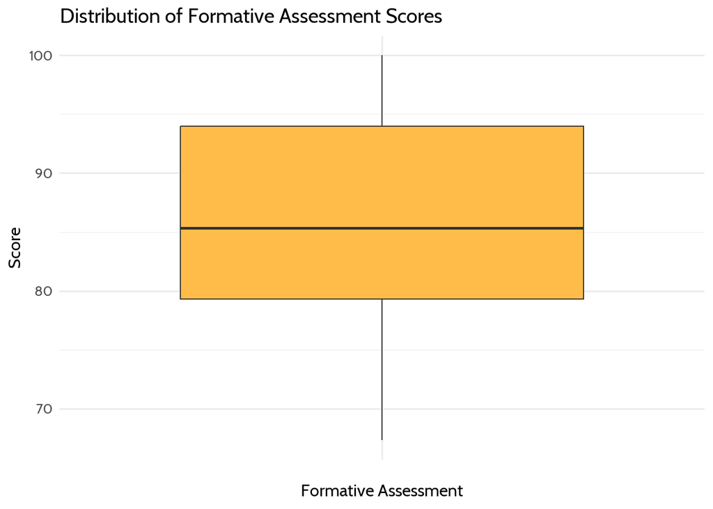

Distribution of Formative Assessment Scores

```r
# Boxplot of formative assessment scores
# To determine if there are any outliers
gradebook %>%
  ggplot(aes(x = "",
             y = formative_assessments)) +
  geom_boxplot(fill = dataedu_colors("yellow")) +
  labs(title = "Distribution of Formative Assessment Scores",
       x = "Formative Assessment",
       y = "Score") +
  theme_dataedu()
```

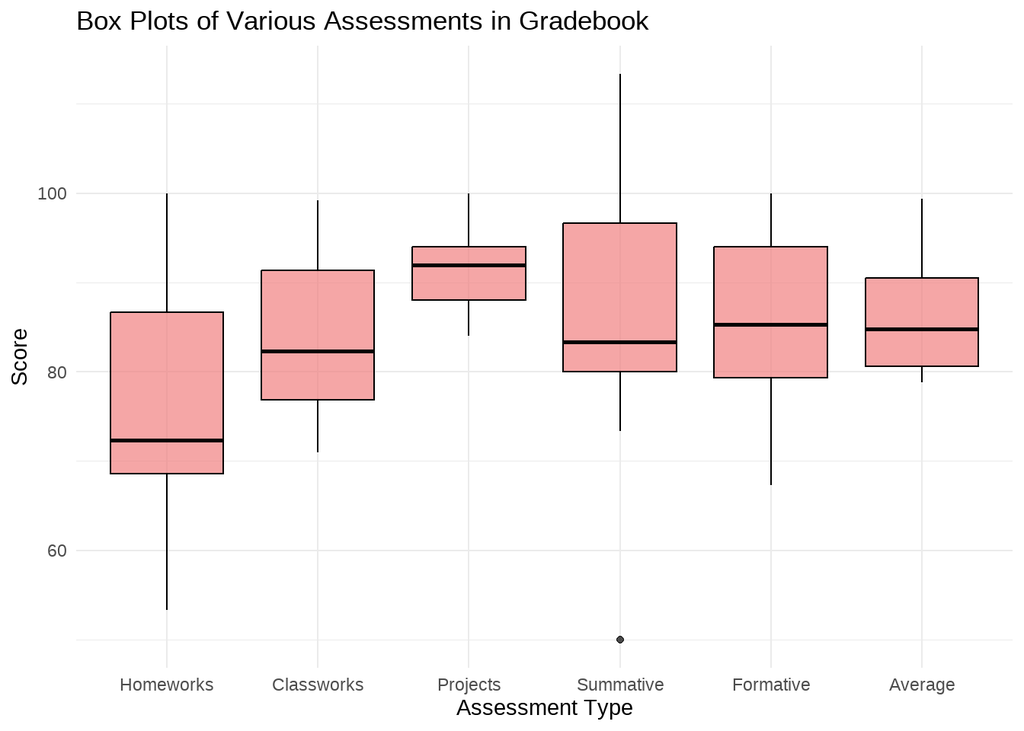

```r
# Assuming 'gradebook' is your dataset
# Load necessary libraries if not already loaded
# install.packages(c("ggplot2", "tidyr"))
library(ggplot2)
library(tidyr)

# Melt the dataset using tidyr::pivot_longer
melted_gradebook <- pivot_longer(gradebook,
                                 cols = c("homeworks", "classworks", "projects", "summative_assessments", "formative_assessments", "running_average"),
                                 names_to = "Assessment_Type",
                                 values_to = "Score")

melted_gradebook$Assessment_Type <- factor(melted_gradebook$Assessment_Type,        levels = c("homeworks", "classworks", "projects", "summative_assessments", "formative_assessments", "running_average"))
# Create box plots for each variable
ggplot(melted_gradebook, aes(x = Assessment_Type, y = Score)) +
  geom_boxplot(fill = "lightcoral", color = "black", alpha = 0.7) +
  labs(title = "Box Plots of Various Assessments in Gradebook", x = "Assessment Type", y = "Score") +
  theme_minimal() +
  scale_x_discrete(labels = c(
    "homeworks" = "Homeworks",
    "classworks" = "Classworks",
    "projects" = "Projects",
    "summative_assessments" = "Summative",
    "formative_assessments" = "Formative",
    "running_average" = "Average"
))
```

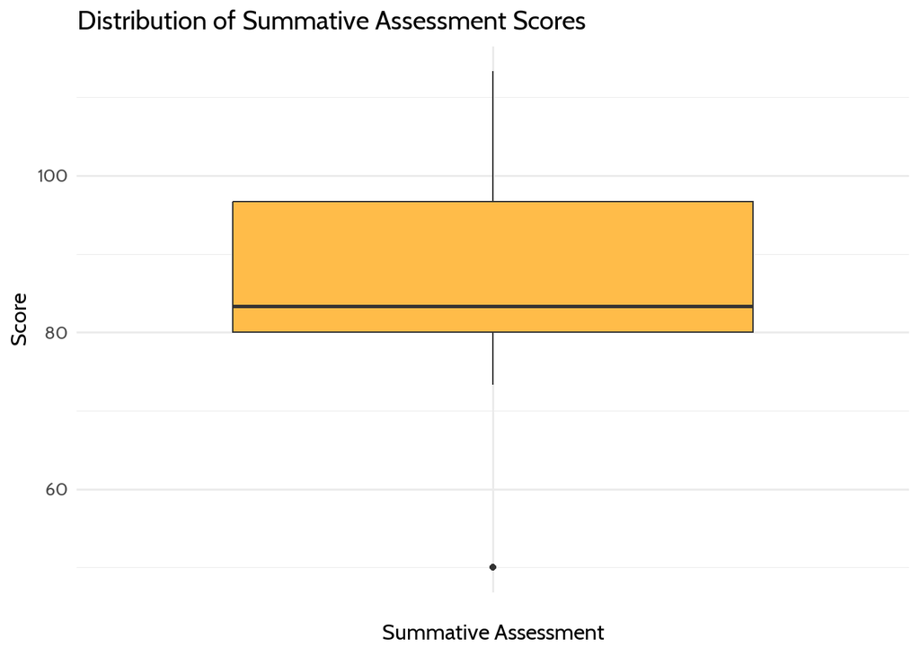

Distribution of Summative Assessment Scores

```r
# Boxplot of summative assessment scores
# To determine if there are any outliers
gradebook %>%
  ggplot(aes(x = "",
             y = summative_assessments)) +
  geom_boxplot(fill = dataedu_colors("yellow")) +
  labs(title = "Distribution of Summative Assessment Scores",
       x = "Summative Assessment",
       y = "Score") +
  theme_dataedu()
```

We remove the outliers in summative assessment because Pearson Correlation Coefficient is sensitive to outliers.

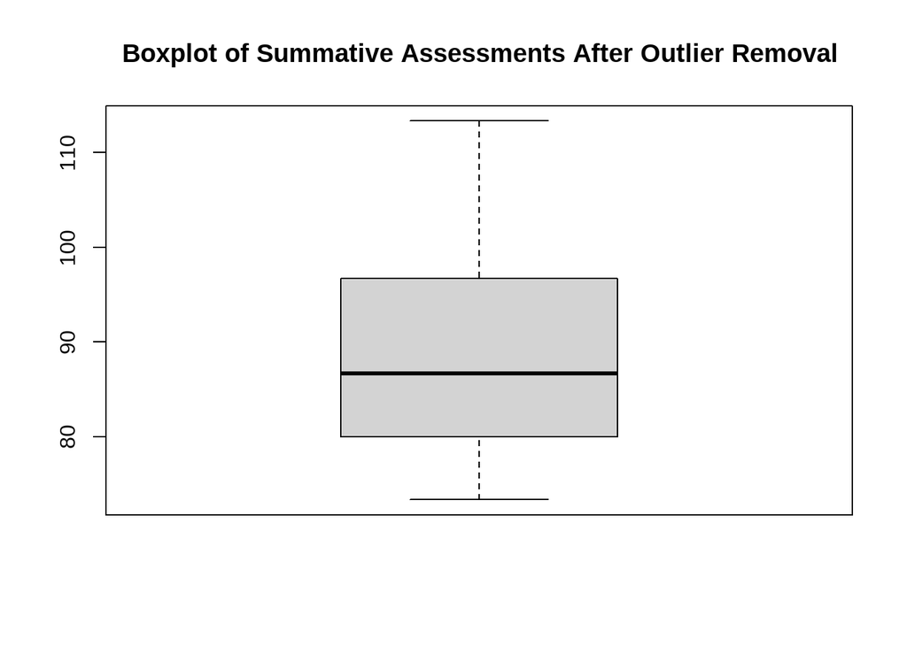

```r
# Extract the column
summative_assessments <- gradebook$summative_assessments

# Calculate the first and third quartiles
Q1 <- quantile(summative_assessments, 0.25)
Q3 <- quantile(summative_assessments, 0.75)

# Calculate the interquartile range (IQR)
IQR_value <- IQR(summative_assessments)

# Define the lower and upper bounds for outliers
lower_bound <- Q1 - 1.5 * IQR_value
upper_bound <- Q3 + 1.5 * IQR_value

# Identify outliers
outliers <- gradebook$summative_assessments[gradebook$summative_assessments < lower_bound | gradebook$summative_assessments > upper_bound]

# Remove outliers
gradebook_no_outliers_summative <- gradebook[gradebook$summative_assessments >= lower_bound & gradebook$summative_assessments <= upper_bound, ]

# To determine if there are any outliers
boxplot(gradebook_no_outliers_summative$summative_assessments, main="Boxplot of Summative Assessments After Outlier Removal")
```

```r
view(outliers)
view(gradebook_no_outliers_summative)
```

**Correlation Analysis**

```r
# Compute Pearson correlation
correlation_coefficient <- cor(gradebook_no_outliers_summative$formative_assessments, gradebook_no_outliers_summative$summative_assessments)

# Assuming x and y are your variables
cor_test_result <- cor.test(gradebook_no_outliers_summative$formative_assessments, gradebook_no_outliers_summative$summative_assessments)

# Access correlation coefficient
cor_coefficient <- cor_test_result$estimate

# Access p-value
p_value <- cor_test_result$p.value

# Print the results
print(paste("Correlation Coefficient (r):", cor_coefficient))
```

```
## [1] "Correlation Coefficient (r): 0.507748310235356"
```

```r
print(paste("P-value:", p_value))
```

```
## [1] "P-value: 0.011312189832529"
```

```r
# Print the result
cat("Pearson correlation coefficient between formative and summative assessments:", correlation_coefficient, "\n")
```

```
## Pearson correlation coefficient between formative and summative assessments: 0.5077483
```

### RQ2: What is the relationship between homework, classwork, and project grades?

**Linearity** Already did in RQ3

**Normal distribution**

```r
# Shapiro-Wilk normality test
shapiro.test(gradebook$classworks)
```

```
##
##  Shapiro-Wilk normality test
##
## data:  gradebook$classworks
## W = 0.94554, p-value = 0.1986
```

```r
shapiro.test(gradebook$homeworks)
```

```
##
##  Shapiro-Wilk normality test
##
## data:  gradebook$homeworks
## W = 0.95591, p-value = 0.3391
```

```r
shapiro.test(gradebook$projects)
```

```
##
##  Shapiro-Wilk normality test
##
## data:  gradebook$projects
## W = 0.97724, p-value = 0.8256
```

**Remove outliers** Already did in RQ3.

**Calculate correlation matrix**

```r
my_data <- gradebook[, c('classworks', 'homeworks', 'projects')]
library("Hmisc")
res2 <- rcorr(as.matrix(my_data))
res2
```

```
##            classworks homeworks projects
## classworks       1.00      0.18     0.41
## homeworks        0.18      1.00     0.61
## projects         0.41      0.61     1.00
##
## n= 25
##
##
## P
##            classworks homeworks projects
## classworks            0.3810    0.0392
## homeworks  0.3810               0.0011
## projects   0.0392     0.0011
```

### RQ3: What has a stronger impact on the final grade: homework, classwork, or project grades?

**Linearity**

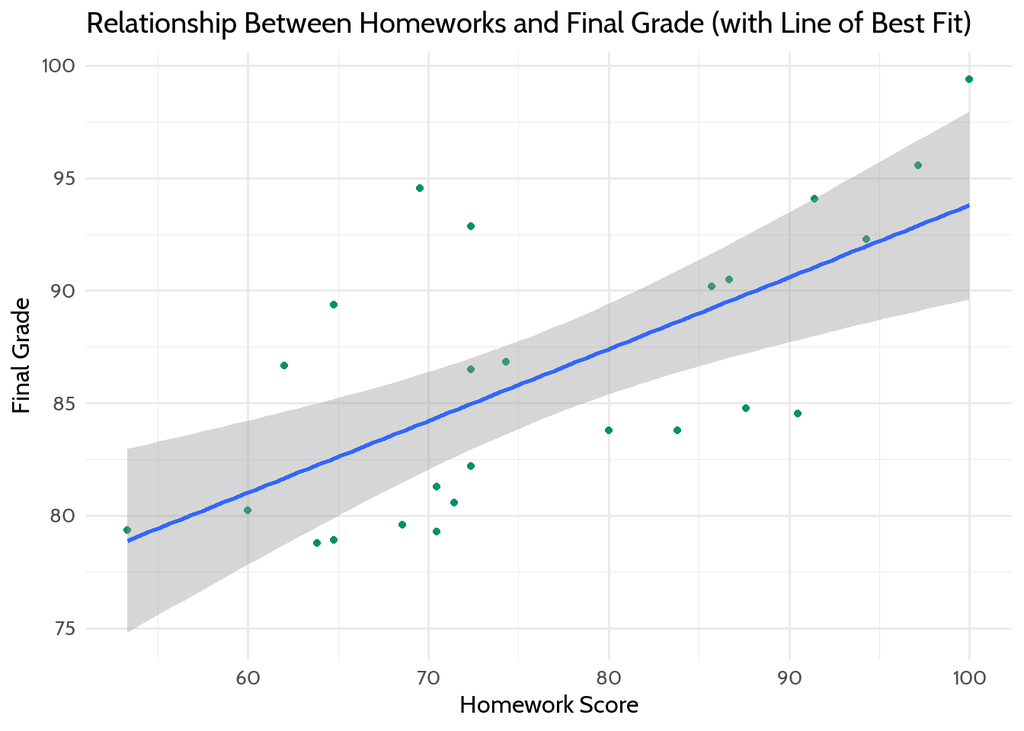

```r
# Scatter plot between homeworks and grades by percent
gradebook %>%
  ggplot(aes(x = homeworks,
             y = running_average)) +
  geom_point(color = dataedu_colors("green")) +
  geom_smooth(method = "lm",
              se = TRUE) +
  labs(title = "Relationship Between Homeworks and Final Grade (with Line of Best Fit)",
       x = "Homework Score",
       y = "Final Grade") +
  theme_dataedu()
```

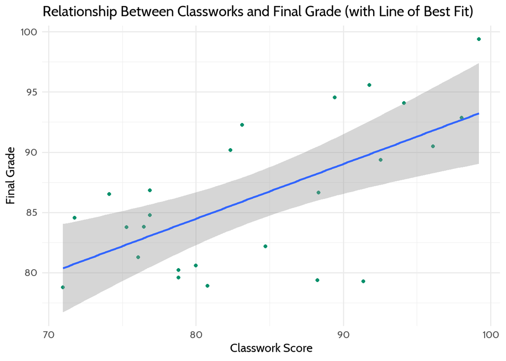

```r
# Scatter plot between classworks and grades by percent
gradebook %>%
  ggplot(aes(x = classworks,
             y = running_average)) +
  geom_point(color = dataedu_colors("green")) +
  geom_smooth(method = "lm",
              se = TRUE) +
  labs(title = "Relationship Between Classworks and Final Grade (with Line of Best Fit)",
       x = "Classwork Score",
       y = "Final Grade") +
  theme_dataedu()
```

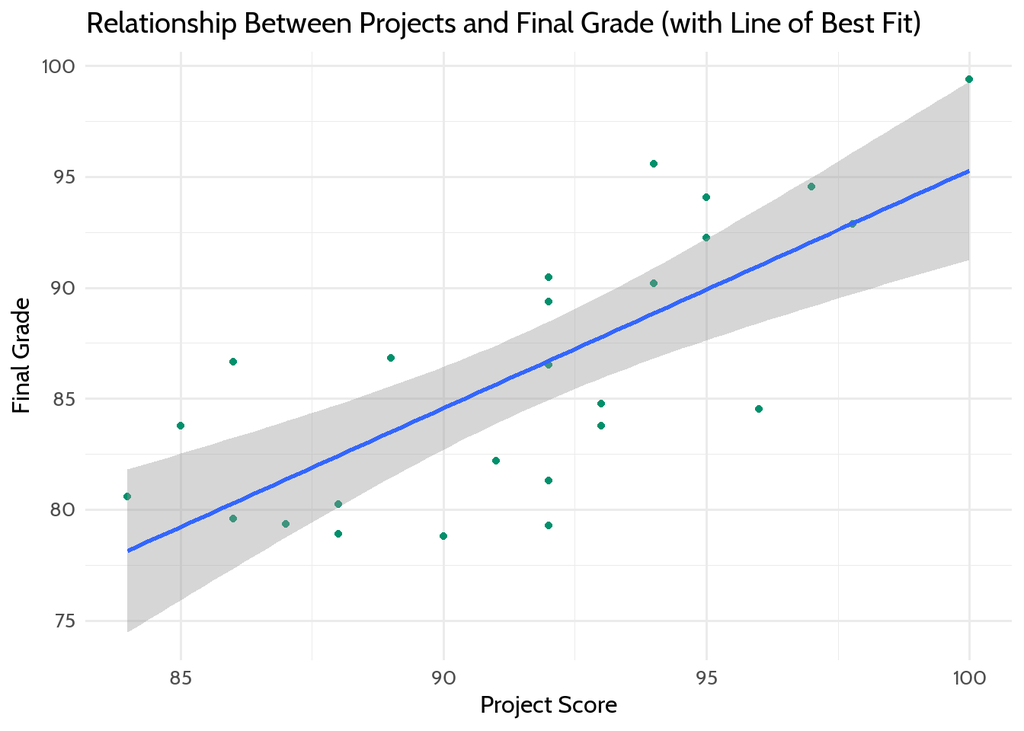

```r
# Scatter plot between projects and grades by percent
gradebook %>%
  ggplot(aes(x = projects,
             y = running_average)) +
  geom_point(color = dataedu_colors("green")) +
  geom_smooth(method = "lm",
              se = TRUE) +
  labs(title = "Relationship Between Projects and Final Grade (with Line of Best Fit)",
       x = "Project Score",
       y = "Final Grade") +
  theme_dataedu()
```

**Homoscedasticity**

```r
# Perform Breusch-Pagan for classwork
model_classwork <- lm(classworks ~ running_average, data = gradebook)
bp_test_classwork <- ncvTest(model_classwork)
print(bp_test_classwork)
```

```
## Non-constant Variance Score Test
## Variance formula: ~ fitted.values
## Chisquare = 0.666107, Df = 1, p = 0.41441
```

```r
# Perform Breusch-Pagan for homework
model_homework <- lm(homeworks ~ running_average, data = gradebook)
bp_test_homework <- ncvTest(model_homework)
print(bp_test_homework)
```

```
## Non-constant Variance Score Test
## Variance formula: ~ fitted.values
## Chisquare = 1.014815, Df = 1, p = 0.31375
```

```r
# Perform Breusch-Pagan for project
model_project <- lm(projects ~ running_average, data = gradebook)
bp_test_project <- ncvTest(model_project)
print(bp_test_project)
```

```
## Non-constant Variance Score Test
## Variance formula: ~ fitted.values
## Chisquare = 0.8795027, Df = 1, p = 0.34834
```

All of the p-values are greater than 0.05, so we can assume homoscedasticity.

**Multicollinearity**

```r
#define multiple linear regression model
model <- lm(running_average ~ classworks + homeworks + projects, data=gradebook)

#calculate the VIF for each predictor variable in the model
vif(model)
```

```
## classworks  homeworks   projects
##   1.220112   1.622851   1.894523
```

Since each of the VIF values for the predictor variables in the model are close to 1, multicollinearity is not a problem in the model.

**Outliers**

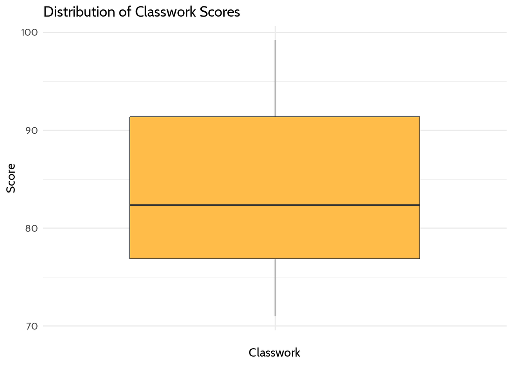

```r
# check for outliers in classwork
gradebook %>%
  ggplot(aes(x = "",
             y = classworks)) +
  geom_boxplot(fill = dataedu_colors("yellow")) +
  labs(title = "Distribution of Classwork Scores",
       x = "Classwork",
       y = "Score") +
  theme_dataedu()
```

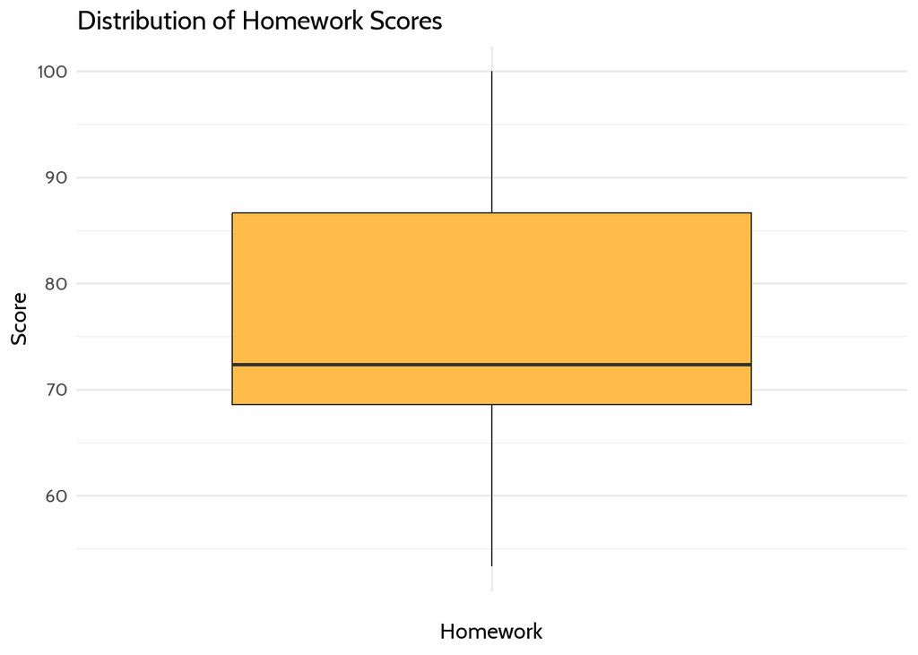

```r
# check for outliers in homework
gradebook %>%
  ggplot(aes(x = "",
             y = homeworks)) +
  geom_boxplot(fill = dataedu_colors("yellow")) +
  labs(title = "Distribution of Homework Scores",
       x = "Homework",
       y = "Score") +
  theme_dataedu()
```

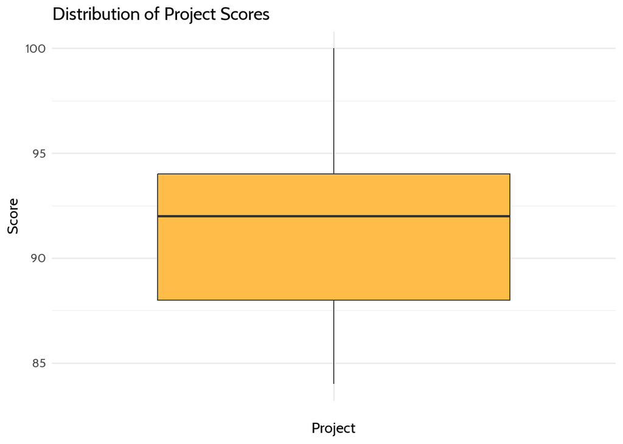

```r
# check for outliers in projects
gradebook %>%
  ggplot(aes(x = "",
             y = projects)) +
  geom_boxplot(fill = dataedu_colors("yellow")) +
  labs(title = "Distribution of Project Scores",
       x = "Project",
       y = "Score") +
  theme_dataedu()
```

No outliers are present.

**Normal distributions of residuals**

```r
# Perform normality test to check for normal distributions of residuals
ols_test_normality(model_classwork)
```

```
## -----------------------------------------------
##        Test             Statistic       pvalue
## -----------------------------------------------
## Shapiro-Wilk              0.9669         0.5684
## Kolmogorov-Smirnov        0.1363         0.6920
## Cramer-von Mises          1.7783         0.0000
## Anderson-Darling          0.3148         0.5223
## -----------------------------------------------
```

```r
ols_test_normality(model_homework)
```

```
## -----------------------------------------------
##        Test             Statistic       pvalue
## -----------------------------------------------
## Shapiro-Wilk              0.9518         0.2757
## Kolmogorov-Smirnov        0.1392         0.6675
## Cramer-von Mises          2.2567         0.0000
## Anderson-Darling          0.4922         0.1986
## -----------------------------------------------
```

```r
ols_test_normality(model_project)
```

```
## -----------------------------------------------
##        Test             Statistic       pvalue
## -----------------------------------------------
## Shapiro-Wilk              0.9742         0.7519
## Kolmogorov-Smirnov        0.0784         0.9946
## Cramer-von Mises          1.4168          2e-04
## Anderson-Darling          0.2321         0.7771
## -----------------------------------------------
```

**Compute the model coefficients**

```r
summary(model)
```

```
##
## Call:
## lm(formula = running_average ~ classworks + homeworks + projects,
##     data = gradebook)
##
## Residuals:
##     Min      1Q  Median      3Q     Max
## -8.4017 -1.8332  0.0448  1.8506  5.3552
##
## Coefficients:
##             Estimate Std. Error t value Pr(>|t|)
## (Intercept)  3.63087   15.49712   0.234  0.81703
## classworks   0.31029    0.08437   3.678  0.00140 **
## homeworks    0.18729    0.06552   2.859  0.00941 **
## projects     0.46192    0.21392   2.159  0.04254 *
## ---
## Signif. codes:  0 '***' 0.001 '**' 0.01 '*' 0.05 '.' 0.1 ' ' 1
##
## Residual standard error: 3.175 on 21 degrees of freedom
## Multiple R-squared:  0.7623, Adjusted R-squared:  0.7283
## F-statistic: 22.44 on 3 and 21 DF,  p-value: 9.417e-07
```

All of the independent variables are significant positive predictors of final grade. Classwork scores are the most important, followed by homework scores and project scores.

### RQ4: Better late or absent? What is the impact of being late vs. being absent?

**Simulate data**

First, we need to simulate some data. Since we already have some data in these columns, we fit a zero-inflated negative binomial model to the existing data, then simulate new data based on the count distribution of the existing data.

```r
# Replace "no match" with NA in the 'late' column
gradebook$late[gradebook$late == "No match"] <- NA

# Replace "no match" with NA in the 'absent' column
gradebook$absent[gradebook$absent == "No match"] <- NA

library(pscl)
# Identify the rows with original data
original_data_late <- !is.na(gradebook$late)
original_data_absent <- !is.na(gradebook$absent)

# Fit a zero-inflated negative binomial model to the existing data
fit_late <- zeroinfl(late ~ 1, dist = "negbin", data = gradebook)
fit_absent <- zeroinfl(absent ~ 1, dist = "negbin", data = gradebook)

# Get the probability of zero-inflation
p_late <- predict(fit_late, type = "zero")
p_absent <- predict(fit_absent, type = "zero")

# Get the mean of the count distribution
lambda_late <- predict(fit_late, type = "count")
lambda_absent <- predict(fit_absent, type = "count")

# Simulate the distribution for new data in the remaining rows
gradebook$simulated_late <- gradebook$late  # Create a new column with the original data
gradebook$simulated_absent <- gradebook$absent  # Create a new column with the original data

# Simulate late and absent data for rows where there's no original data
set.seed(1)

gradebook$simulated_late[!original_data_late] <- ifelse(rbinom(sum(!original_data_late), size = 1, prob = p_late) > 0, 0, rpois(sum(!original_data_late), lambda = lambda_late))

gradebook$simulated_absent[!original_data_absent] <- ifelse(rbinom(sum(!original_data_absent), size = 1, prob = p_absent) > 0, 0, rpois(sum(!original_data_absent), lambda = lambda_absent))

# Convert simulated late and absent data to numeric and store them in columnes "late" and "absent"
gradebook$late <- as.numeric(gradebook$simulated_late)
gradebook$absent <- as.numeric(gradebook$simulated_absent)
```

**Create bar charts for ‘late’ and ‘absent’**

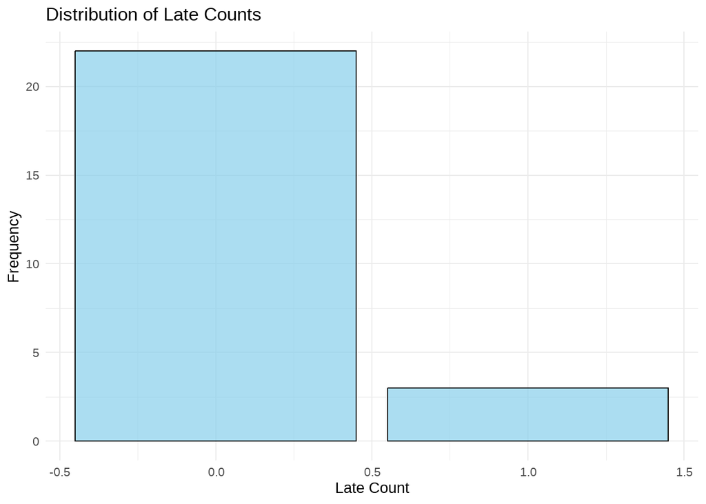

```r
library(ggplot2)

# Bar chart for 'late'
ggplot(gradebook, aes(x = late)) +
  geom_bar(fill = "skyblue", color = "black", alpha = 0.7) +
  labs(title = "Distribution of Late Counts", x = "Late Count", y = "Frequency") +
  theme_minimal()
```

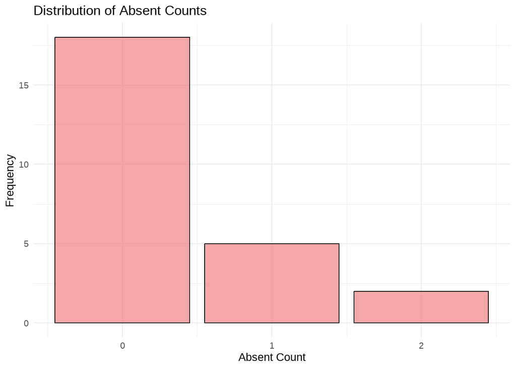

```r
# Bar chart for 'absent'
ggplot(gradebook, aes(x = absent)) +
  geom_bar(fill = "lightcoral", color = "black", alpha = 0.7) +
  labs(title = "Distribution of Absent Counts", x = "Absent Count", y = "Frequency") +
  theme_minimal()
```

**Homoscedasticity**

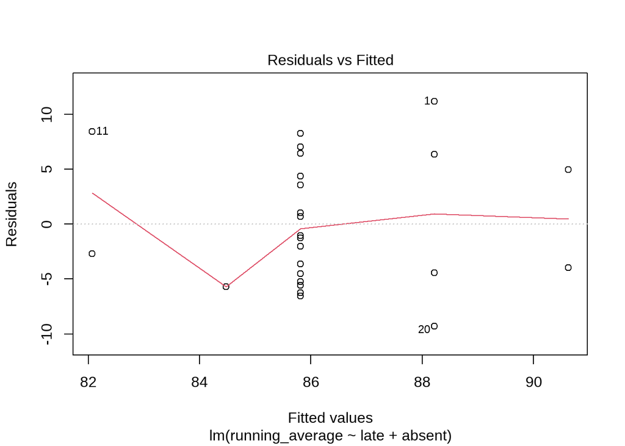

```r
model_late_absent <- lm(running_average ~ late + absent, data=gradebook)
residuals <- residuals(model_late_absent)
plot(model_late_absent, which = 1)
```

**Multicollinearity**

```r
car::vif(model_late_absent)
```

```
##     late   absent
## 1.000248 1.000248
```

**Normal distribution of errors**

```r
ols_test_normality(model_late_absent)
```

```
## -----------------------------------------------
##        Test             Statistic       pvalue
## -----------------------------------------------
## Shapiro-Wilk              0.9374         0.1286
## Kolmogorov-Smirnov        0.1359         0.6949
## Cramer-von Mises          2.0105         0.0000
## Anderson-Darling          0.6524         0.0783
## -----------------------------------------------
```

**Run MLR model**

```r
summary(model_late_absent)
```

```
##
## Call:
## lm(formula = running_average ~ late + absent, data = gradebook)
##
## Residuals:
##    Min     1Q Median     3Q    Max
## -9.319 -4.529 -1.276  4.945 11.164
##
## Coefficients:
##             Estimate Std. Error t value Pr(>|t|)
## (Intercept)   85.812      1.461  58.745   <2e-16 ***
## late          -3.742      3.701  -1.011    0.323
## absent         2.406      1.925   1.250    0.224
## ---
## Signif. codes:  0 '***' 0.001 '**' 0.01 '*' 0.05 '.' 0.1 ' ' 1
##
## Residual standard error: 6.013 on 22 degrees of freedom
## Multiple R-squared:  0.1066, Adjusted R-squared:  0.02537
## F-statistic: 1.312 on 2 and 22 DF,  p-value: 0.2894
```

### RQ5: What has a stronger impact on final grade: race or gender?

**Generate random data**

```r
set.seed(1)

# Generate random gender data
gradebook$gender <- sample(c("Male", "Female"), nrow(gradebook), replace = TRUE)

#Generate random race data
gradebook$race <- sample(c("Caucasian", "Asian", "Black"), nrow(gradebook), replace = TRUE)

# Print the first few rows of the data frame
head(gradebook)
```

```
## # A tibble: 6 × 61
##   class name    race  gender age   financial_status absent  late running_average
##   <dbl> <chr>   <chr> <chr>  <lgl> <lgl>             <dbl> <dbl>           <dbl>
## 1     1 Studen… Cauc… Male   NA    NA                    1     0            99.4
## 2     1 Studen… Asian Female NA    NA                    0     1            79.4
## 3     1 Studen… Cauc… Male   NA    NA                    2     0            86.6
## 4     1 Studen… Cauc… Male   NA    NA                    0     0            80.2
## 5     1 Studen… Asian Female NA    NA                    0     0            86.5
## 6     1 Studen… Asian Male   NA    NA                    0     0            83.8
## # ℹ 52 more variables: letter_grade <chr>, homeworks <dbl>, classworks <dbl>,
## #   formative_assessments <dbl>, projects <dbl>, summative_assessments <dbl>,
## #   classwork_1 <dbl>, homework_1 <dbl>, classwork_2 <dbl>, homework_2 <chr>,
## #   classwork_3 <chr>, classwork_4 <dbl>, classwork_5 <dbl>, classwork_6 <dbl>,
## #   homework_3 <dbl>, formative_assessment_1 <dbl>, project_1 <dbl>,
## #   classwork_7 <dbl>, homework_4 <dbl>, project_2 <chr>, classwork_8 <dbl>,
## #   homework_5 <dbl>, project_3 <dbl>, homework_6 <dbl>, classwork_9 <dbl>, …
```

**Visualize data**

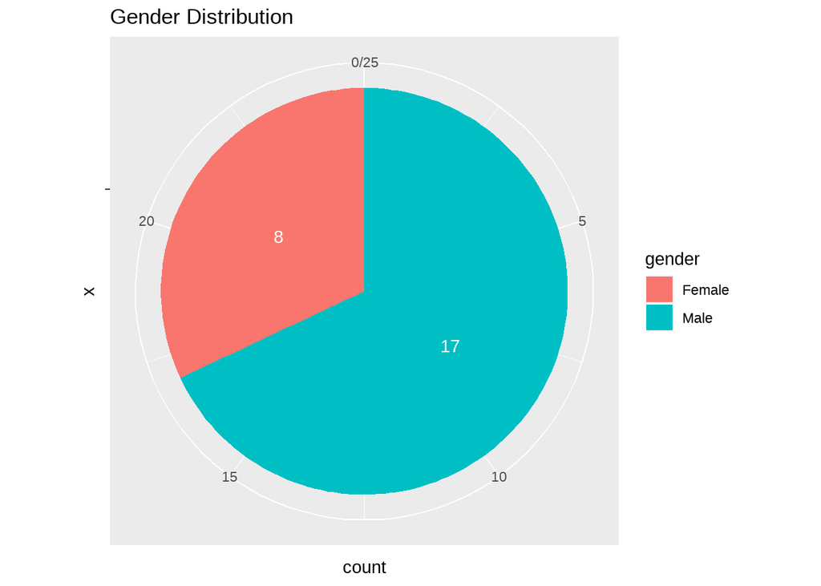

```r
library(ggplot2)

# Pie chart for gender
ggplot(gradebook, aes(x = "", fill = gender)) +
  geom_bar(width = 1, stat = "count") +
  geom_text(aes(label = stat(count), group = gender), stat = "count", position = position_stack(vjust = 0.5), color = "white") +
  coord_polar(theta = "y") +
  labs(title = "Gender Distribution")
```

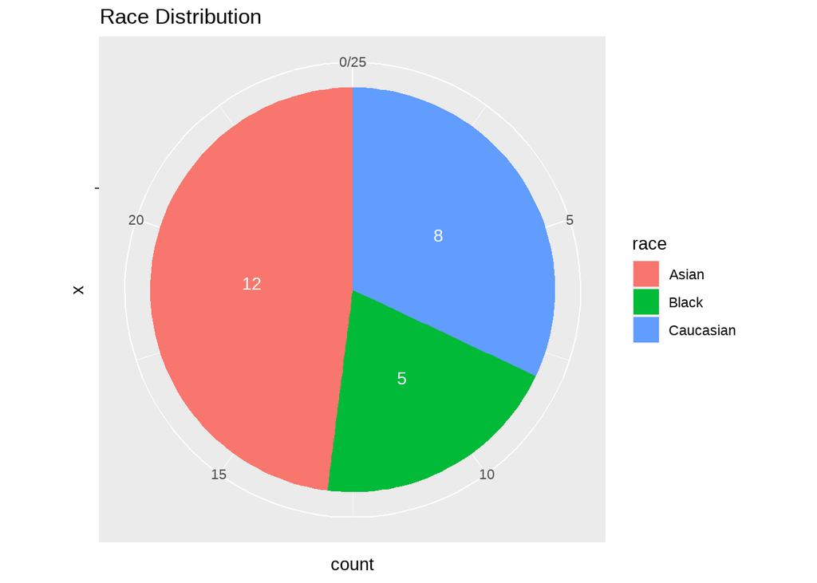

```r
# Pie chart for race
ggplot(gradebook, aes(x = "", fill = race)) +
  geom_bar(width = 1, stat = "count") +
  geom_text(aes(label = stat(count), group = race), stat = "count", position = position_stack(vjust = 0.5), color = "white") +
  coord_polar(theta = "y") +
  labs(title = "Race Distribution")
```

**Homoscedasticity**

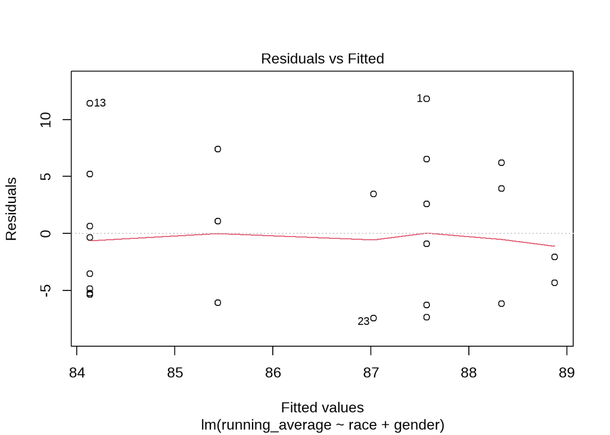

```r
model_race_gender <- lm(running_average ~ race + gender, data=gradebook)
residuals <- residuals(model_race_gender)
plot(model_race_gender, which = 1)
```

**Multicollinearity**

```r
car::vif(model_race_gender)
```

```
##           GVIF Df GVIF^(1/(2*Df))
## race   1.09899  2        1.023879
## gender 1.09899  1        1.048327
```

**Normal distribution of errors**

```r
ols_test_normality(model_race_gender)
```

```
## -----------------------------------------------
##        Test             Statistic       pvalue
## -----------------------------------------------
## Shapiro-Wilk              0.9313         0.0933
## Kolmogorov-Smirnov        0.1325         0.7240
## Cramer-von Mises          1.9988         0.0000
## Anderson-Darling          0.5194         0.1691
## -----------------------------------------------
```

**Run MLR**

```r
summary(model_race_gender)
```

```
##
## Call:
## lm(formula = running_average ~ race + gender, data = gradebook)
##
## Residuals:
##     Min      1Q  Median      3Q     Max
## -7.4506 -5.2339 -0.3503  3.9297 11.8146
##
## Coefficients:
##               Estimate Std. Error t value Pr(>|t|)
## (Intercept)     85.440      2.756  31.003   <2e-16 ***
## raceBlack        2.894      3.447   0.840    0.411
## raceCaucasian    3.435      2.834   1.212    0.239
## genderMale      -1.307      2.791  -0.468    0.644
## ---
## Signif. codes:  0 '***' 0.001 '**' 0.01 '*' 0.05 '.' 0.1 ' ' 1
##
## Residual standard error: 6.21 on 21 degrees of freedom
## Multiple R-squared:  0.09068,    Adjusted R-squared:  -0.03923
## F-statistic: 0.698 on 3 and 21 DF,  p-value: 0.5637
```

```r
model_race <- lm(running_average ~ race, data = gradebook)
summary(model_race)
```

```
##
## Call:
## lm(formula = running_average ~ race, data = gradebook)
##
## Residuals:
##     Min      1Q  Median      3Q     Max
## -8.2350 -5.1820 -0.6771  4.4525 11.4878
##
## Coefficients:
##               Estimate Std. Error t value Pr(>|t|)
## (Intercept)     84.459      1.760  47.976   <2e-16 ***
## raceBlack        3.352      3.246   1.032    0.313
## raceCaucasian    3.435      2.784   1.234    0.230
## ---
## Signif. codes:  0 '***' 0.001 '**' 0.01 '*' 0.05 '.' 0.1 ' ' 1
##
## Residual standard error: 6.098 on 22 degrees of freedom
## Multiple R-squared:  0.08118,    Adjusted R-squared:  -0.002353
## F-statistic: 0.9718 on 2 and 22 DF,  p-value: 0.3941
```

```r
model_gender <- lm(running_average ~ gender, data = gradebook)
summary(model_gender)
```

```
##
## Call:
## lm(formula = running_average ~ gender, data = gradebook)
##
## Residuals:
##     Min      1Q  Median      3Q     Max
## -8.0319 -5.2041 -0.9298  4.7930 13.6969
##
## Coefficients:
##             Estimate Std. Error t value Pr(>|t|)
## (Intercept)   87.384      2.180  40.077   <2e-16 ***
## genderMale    -1.698      2.644  -0.642    0.527
## ---
## Signif. codes:  0 '***' 0.001 '**' 0.01 '*' 0.05 '.' 0.1 ' ' 1
##
## Residual standard error: 6.167 on 23 degrees of freedom
## Multiple R-squared:  0.01762,    Adjusted R-squared:  -0.02509
## F-statistic: 0.4126 on 1 and 23 DF,  p-value: 0.527
```

### RQ6: What has a stronger impact on final grade: age or financial status?

**Generate random data**

```r
set.seed(1)

# Simulate the 'age' column using a normal distribution
gradebook$age <- round(rnorm(nrow(gradebook), mean = 25, sd = 5))

# Simulate the 'financial_status' column using a normal distribution for scores
gradebook$financial_status <- round(rnorm(nrow(gradebook), mean = 75, sd = 10))
```

**Plot histograms for age and financial status**

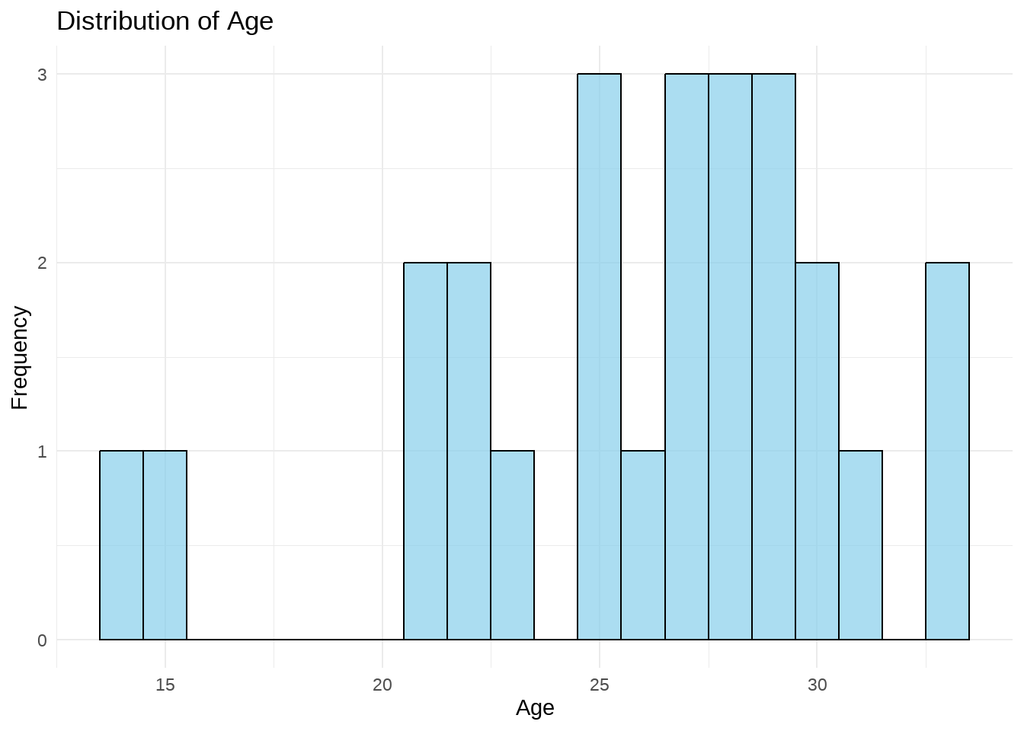

```r
library(ggplot2)

# Histogram for 'age'
ggplot(gradebook, aes(x = age)) +
  geom_histogram(binwidth = 1, fill = "skyblue", color = "black", alpha = 0.7) +
  labs(title = "Distribution of Age", x = "Age", y = "Frequency") +
  theme_minimal()
```

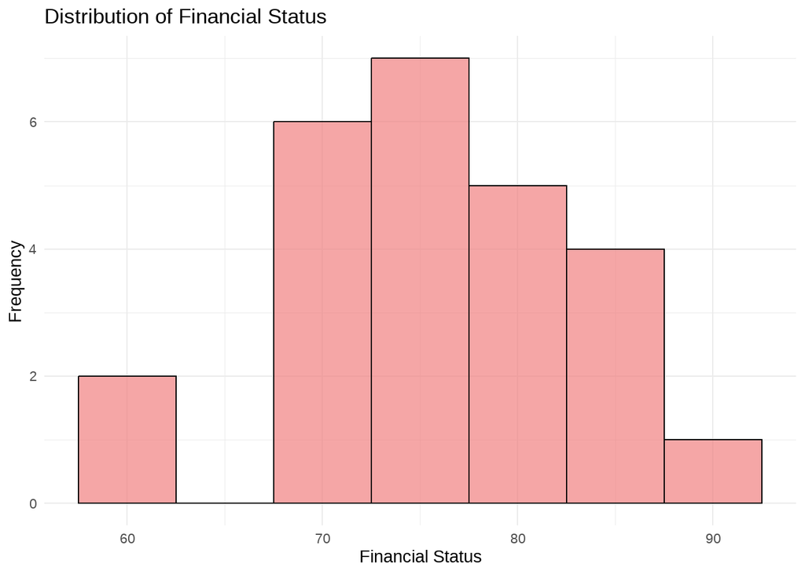

```r
# Histogram for 'financial_status'
ggplot(gradebook, aes(x = financial_status)) +
  geom_histogram(binwidth = 5, fill = "lightcoral", color = "black", alpha = 0.7) +
  labs(title = "Distribution of Financial Status", x = "Financial Status", y = "Frequency") +
  theme_minimal()
```

**Linearity**

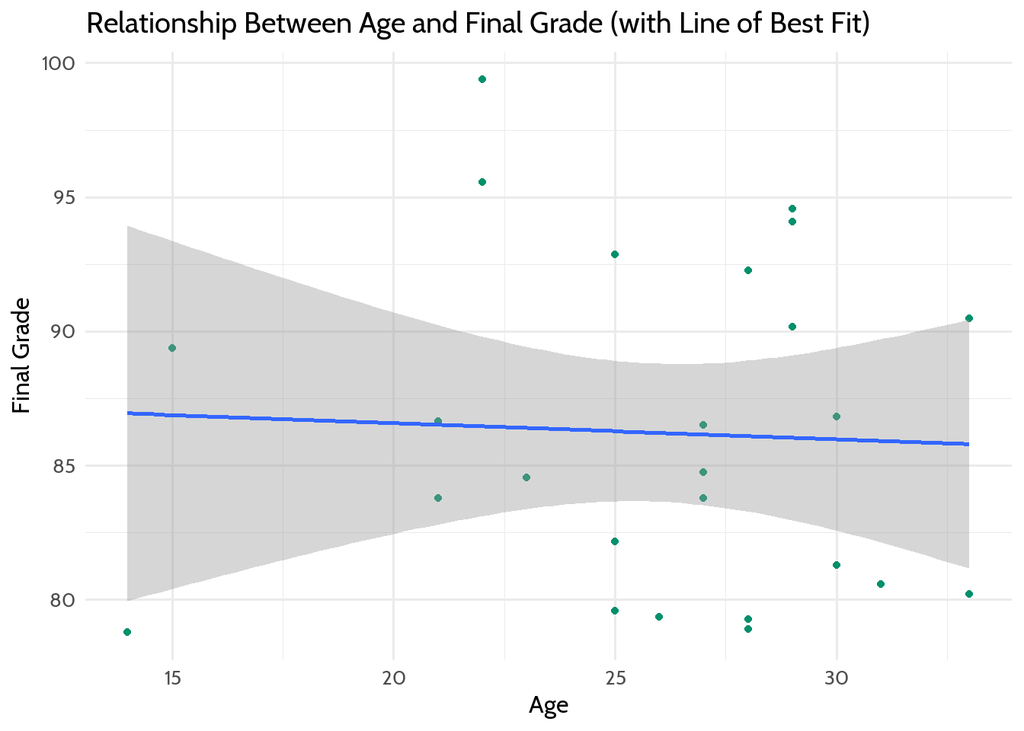

```r
# Scatter plot between age and grades by percent
gradebook %>%
  ggplot(aes(x = age,
             y = running_average)) +
  geom_point(color = dataedu_colors("green")) +
  geom_smooth(method = "lm", se = TRUE) +
  labs(title = "Relationship Between Age and Final Grade (with Line of Best Fit)",
       x = "Age",
       y = "Final Grade") +
  theme_dataedu()
```

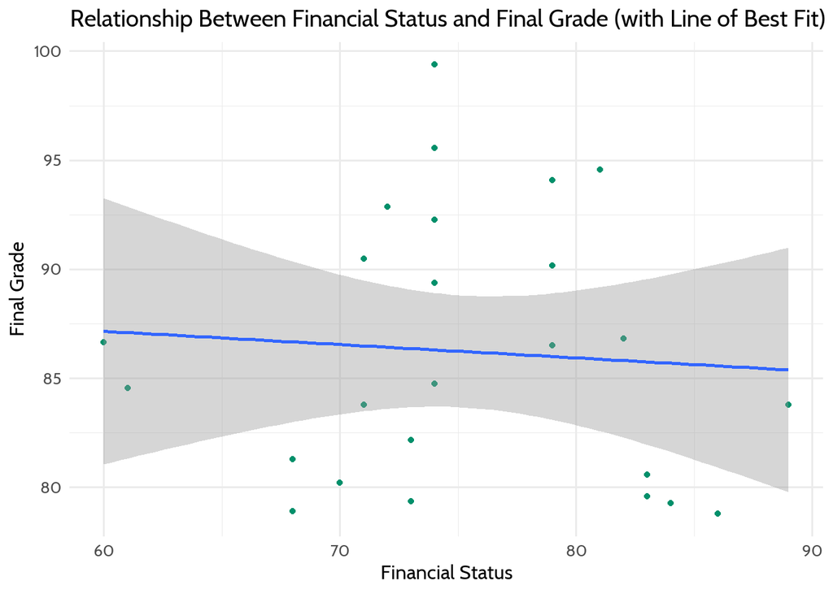

```r
# Scatter plot between financial status and grades by percent
gradebook %>%
  ggplot(aes(x = financial_status,
             y = running_average)) +
  geom_point(color = dataedu_colors("green")) +
  geom_smooth(method = "lm",
              se = TRUE) +
  labs(title = "Relationship Between Financial Status and Final Grade (with Line of Best Fit)",
       x = "Financial Status",
       y = "Final Grade") +
  theme_dataedu()
```

**Loess curve**

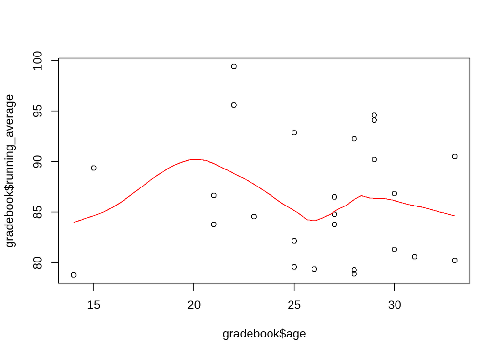

```r
plot(gradebook$age,gradebook$running_average)
lines(loess.smooth(gradebook$age, gradebook$running_average), col = "red")
```

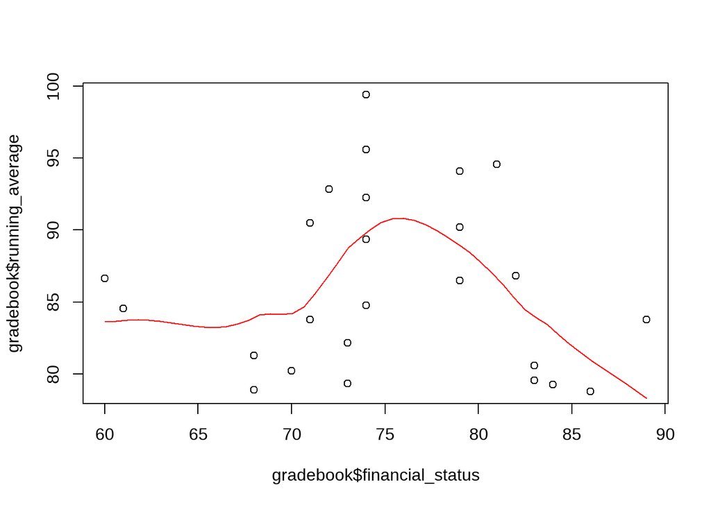

```r
plot(gradebook$financial_status,gradebook$running_average)
lines(loess.smooth(gradebook$financial_status, gradebook$running_average), col = "red")
```

```r
model <- lm(running_average ~ age + financial_status, data = gradebook)
```

**Homoscedasticity**

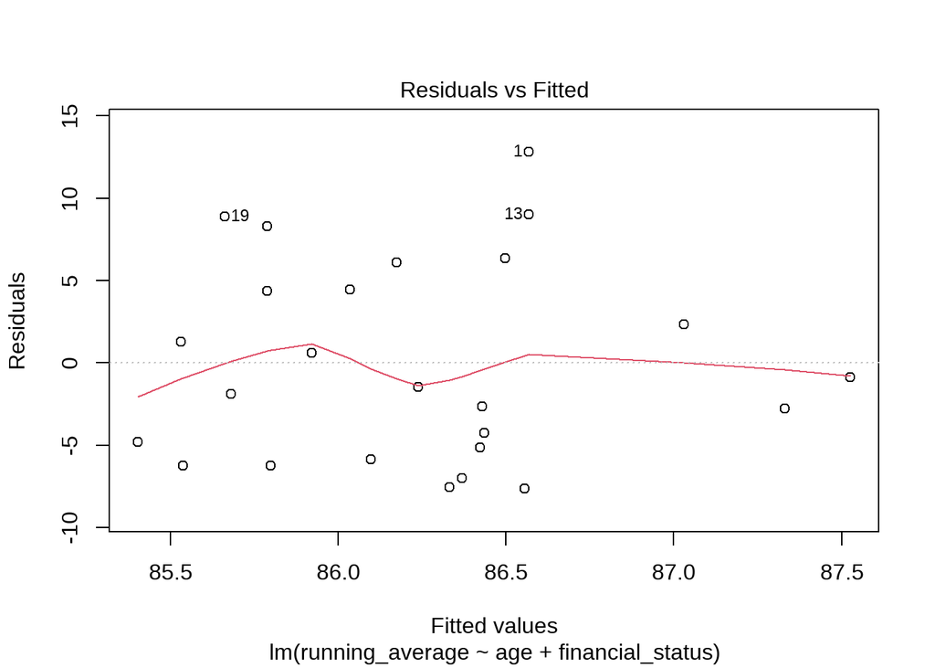

```r
model_age_finance <- lm(running_average ~ age + financial_status, data=gradebook)
residuals <- residuals(model_age_finance)
plot(model_age_finance, which = 1)
```

**Multicollinearity**

```r
vif(model_age_finance)
```

```
##              age financial_status
##         1.003375         1.003375
```

**Normal distribution of errors**

```r
ols_test_normality(model_age_finance)
```

```
## -----------------------------------------------
##        Test             Statistic       pvalue
## -----------------------------------------------
## Shapiro-Wilk              0.9291         0.0827
## Kolmogorov-Smirnov        0.1185         0.8343
## Cramer-von Mises          1.997          0.0000
## Anderson-Darling          0.5878         0.1144
## -----------------------------------------------
```

**Run MLR**

```r
summary(model_age_finance)
```

```
##
## Call:
## lm(formula = running_average ~ age + financial_status, data = gradebook)
##
## Residuals:
##    Min     1Q Median     3Q    Max
## -7.656 -5.140 -1.484  4.444 12.814
##
## Coefficients:
##                  Estimate Std. Error t value Pr(>|t|)
## (Intercept)      92.72788   15.59310   5.947 5.52e-06 ***
## age              -0.06592    0.26923  -0.245    0.809
## financial_status -0.06363    0.17917  -0.355    0.726
## ---
## Signif. codes:  0 '***' 0.001 '**' 0.01 '*' 0.05 '.' 0.1 ' ' 1
##
## Residual standard error: 6.337 on 22 degrees of freedom
## Multiple R-squared:  0.007963,   Adjusted R-squared:  -0.08222
## F-statistic: 0.0883 on 2 and 22 DF,  p-value: 0.9158
```